# RED WINE DATASET ANALYSIS by HUNG TUAN TRUONG

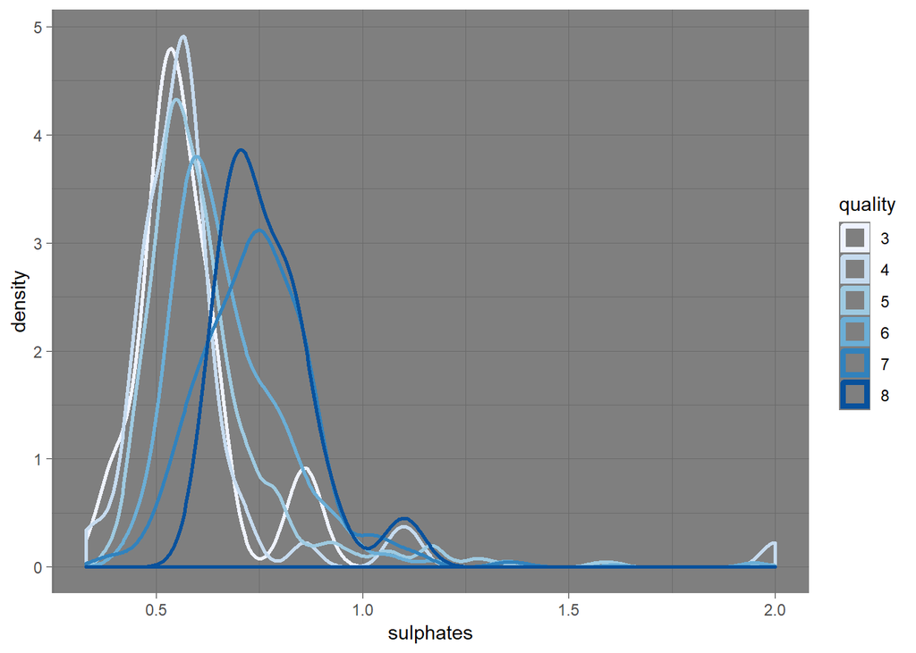

We can easily see that as quality score increases, the lines that correspond with each quality score also shift to the right. This implies that a higher amount of sulphates will lead to an increasing chance of improvement in quality.

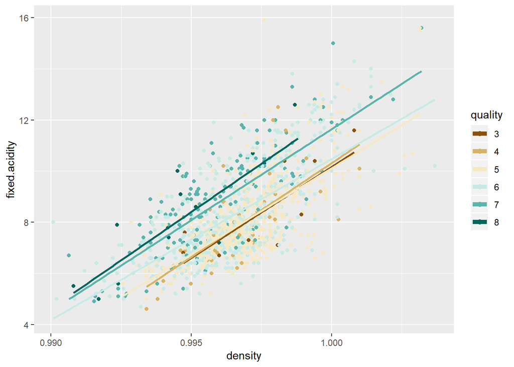

As the amount of fixed acidity increases, the higher quality score of at least 7 also appears more frequently. In addition, we can see that for wines with density below 0.995 g/cm^3, they are predominantly receive the quality score of 6 and above.

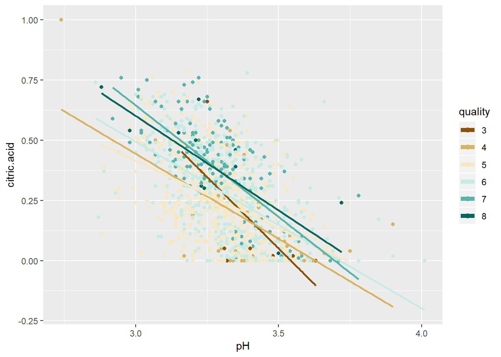

As seen from the plot, wines with the quality score of 6 and above usually have pH approximately less than 3.3 and citric acid amount of more than 0.25 g/dm^3.

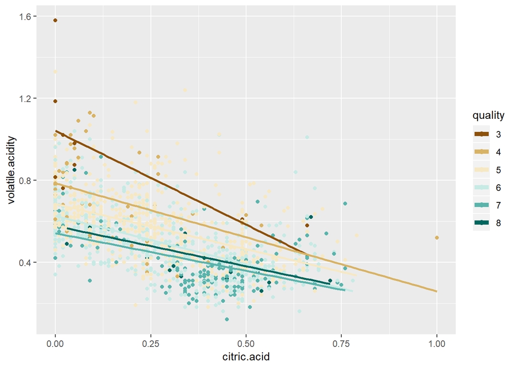

We can see that as volatile acidity amount increases, quality score also drops. This aligns with our previous findings. Furthermore, wines with quality score of 7 and 8 are more likely to contain a citric acid amount of more than 0.25 g/dm^3.

# Multivariate Analysis

### Talk about some of the relationships you observed in this part of the investigation. Were there features that strengthened each other in terms of looking at your feature(s) of interest?

- The density plots of alcohol, volatile acidity, chlorides and sulphates gave us a deeper understanding than what was presented in part 1 and 2 by creating multiple lines in the same plot based upon quality score. In the case of volatile acidity and chlorides, higher scores occur more often as their amount decreases. On the other hand, an increase in the amount of alcohol and sulphates leads to a greater probability of obtaining a higher quality score.
- Higher quality scores are moderately associated with more alcohol, fixed acidity, citric acid and less volatile acidity. A more comprehensive analysis has been provided below each plot in this section.

### Were there any interesting or surprising interactions between features?

- From part 2, we have learnt there seems to be very weak correlation between chlorides and quality score a wine receives. However, in this section, it seems that when chlorides amount exceeds 0.1 g/dm^3, it is much more likely for the low quality score of 3 to appear. The fact that there are only a few wines with this much chlorides amount in the dataset means that this would not be reflected in the correlation value.
- Wines with density of below 0.993 g/cm^3 receive very high quality score of 6 and above. Again since there are not too many wines with this feature, it is not until this section that this has finally been found out.

# Final Plots and Summary

### Plot One

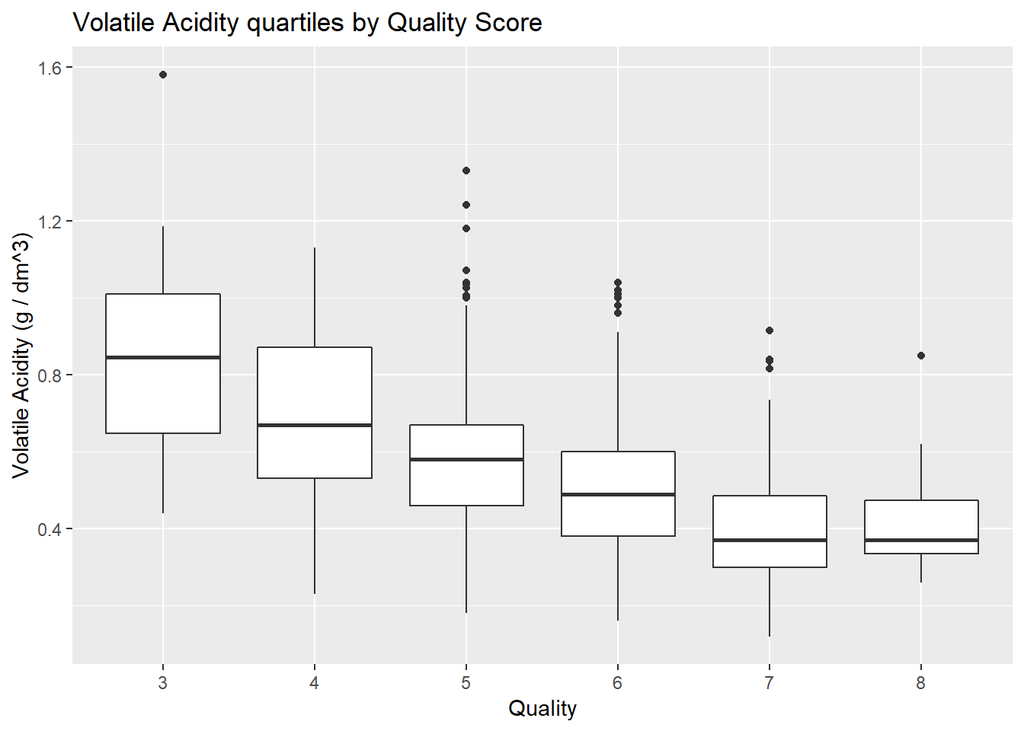

### Description One

Wines with lowest quality score of 3 in the dataset have the highest median volatile acidity amount, whereas those with highest quality score of 7 or 8 have the lowest median volatile acidity value. To put it another way, as quality score improves, the median volatile acidity amount also drops.

The same trend could also be seen for the third quartile and to a lesser extent, the first quartile values. Regarding the first quartile, its value decreases as quality score goes up until 8, where it appears to move up a little bit.

### Plot Two

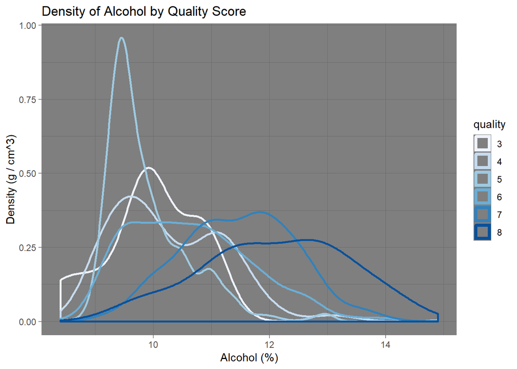

### Description Two

Low quality scores such as 3 or 4 appear more often when the alcohol percentage is small, specifically below 12 percent. As the alcohol percentage increases, higher quality scores like 7 or 8 also occur more frequently.

In addition, low quality scores like 3, 4 or 5 typically reach their peaks when alcohol percentage is below 10 and begin to drop significantly after that, when they are slowly taken over by higher quality scores.

### Plot Three

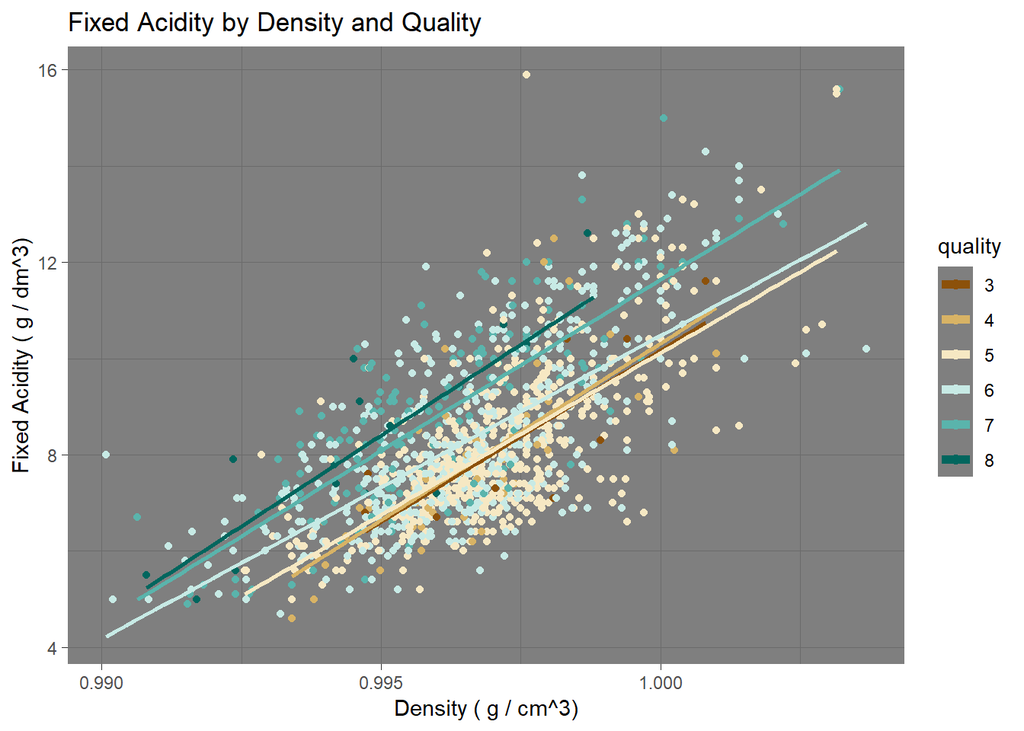

### Description Three

The above scatter plot of fixed acidity by density and quality reveals that when density remains the same, it is very likely for wines with higher amount of fixed acidity to receive a better quality score like 7 or 8. ——

# Reflection

This project is so far the one that I have put the most effort in to have it completed before the deadline. R is a entirely new language to me and this project is also the first time I have written code with R. Needless to say, it takes countless time of revisiting Udacity lessons to figure out how to create certain kinds of plots. The most challenging part is the multivariate analysis section, because at the beginning it is not clear which direction I should take, or which variable I should add to the plots to further explore the dataset. The fact that this lesson simply does not hold one’s hand, or have a template on what I need to do also makes it more complex than some of the other previous projects. Regarding the red wine dataset, none of the features seem to strongly correlate to one another, which adds another layer of complexity to the whole project. Perhaps with a larger dataset, we would be able to find even more correlations and hidden insights among all the variables. Future projects could be done with more complicated analysis techniques or include a linear model to predict main variable’s value such as price or quality score based upon some other supporting features.